# Données aberrantes avec approche univariée

Les valeurs aberrantes peuvent survenir pour diverses raisons, dont la plus évidente est lors d’erreurs de mesure, erreurs de transcription des données, etc.

Cependant, les valeurs aberrantes ne sont pas forcément erronées. Parfois, elles sont des valeurs qui révèlent un phénomène particulier qui peut être différent du modèle suivi par la majorité des observations.

```
## [1] 183928     41
```

```
##  [1] "X.1"                 "X"                   "Timestamp"
##  [4] "Site_ID"             "Warning_flags"       "Subclass_ID"
##  [7] "Axle_groups"         "A1"                  "A2"
## [10] "A3"                  "A4"                  "A5"
## [13] "A6"                  "A7"                  "Date"
## [16] "Horaire"             "Annee"               "Mois_num"
## [19] "Mois_annee"          "Jour_num"            "Jour_semaine"
## [22] "Heure"               "M1"                  "M2"
## [25] "M3"                  "M4"                  "M5"
## [28] "M6"                  "M7"                  "M8"
## [31] "Lane"                "N"                   "Nb_axles"
## [34] "Anomalie"            "total_axle_dist"     "T"
## [37] "Reduced_chi_squared" "Time_num"            "Vitesse"
## [40] "MGV"                 "clusters_kmeans"
```

# Méthodologie

Les variables en notre possession sont:

- Des paramètres physiques du véhicule: poids total, poids sur essieux, distances entre essieux,
- Des variables d’environnement: date et heure de passage, température,
- Des variables liées au passage du véhicule: vitesse, voie de passage,
- Des variables liées au traitement mathématique et numérique du problème inverse: la mesure du chi2 entre mesure et calcul, différents “warnings” tags quant aux traitements réalisés.

Nous allons utiliser une approche univariée puis une approche multivariée pour déterminer les outliers.

L’approche univariée, comme son nom l’indique, recherche les outliers par rapport à une seule variable. Une observation qui est inconditionnelle non usuelle est appelée “univariate outlier”, donnée aberrante univariée.

L’approche multivariée passe par la recherche d’un modèle entre les variables en présence. Les outliers sont alors déterminés avec différentes distances (Cook, residual, r-strudent, les hatvalues, Mahalanobis, DFFITS), voir (Outlier detection in multivariate data, K. Senthamarai, K. Manoj, Applied Mathematical Sciences, 2015). Une donnée aberrante multivariée est une donnée qui a une valeur non usuelle de la variable $Y$, conditionnellement à la valeur de la/des variable(s) $X$ ($X_i$).

A noter qu’il existe différents packages qui permettent de traiter le problème des outliers (car, outlierD, …), mais nous avons poréféré ici passer par la recherche de modèles.

# Approche univariée

Tout d’abord nous créons le dataframe correspondant où les variables manquantes (typiquement les poids des essieux non existants) sont ramenées à 0:

```
## [1] 183928     21
```

```
##  [1] "Warning_flags"       "A1"                  "A2"
##  [4] "A3"                  "A4"                  "A5"
##  [7] "A6"                  "A7"                  "M1"
## [10] "M2"                  "M3"                  "M4"
## [13] "M5"                  "M6"                  "M7"
## [16] "M8"                  "N"                   "Reduced_chi_squared"
## [19] "Vitesse"             "MGV"                 "clusters_kmeans"
```

Un outlier est un individu dont la variable étudiée est en dehors de 1.5*IQR, avec IQR (Inter Quartile Range) est la différence entre le 75et 25quantile.

Cette recherche de outliers peut se faire en univariée à l’aide de bowplot.

Les sorties de la fonction boxplot sont:

- stats: vecteur de longueur 5, qui contient la valeur extrême de la moustache inférieure, la charnière inférieure, la médiane, la charbnière supérieure et la valeur extrême de la moustache supérieure.
- n: le nombre d’observations NA dans l’échantillon.
- conf: les valeurs inférieures et supérieures du ‘notch’ (if(do.conf)).
- out : les valeurs des points en dehors des extrêmes des moustaches.

Ici nous effectuons ce test pour différentes variables puis créons une colonne supplémentaire dans nos données qui identifie l’individu comme un outlier (“TRUE”) ou pas(“FALSE).

## Pour le poids total en charge

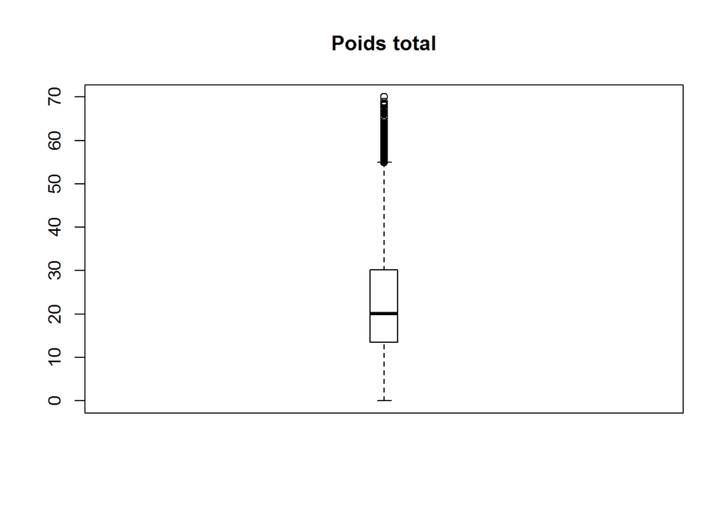

```
## [1] 142
```

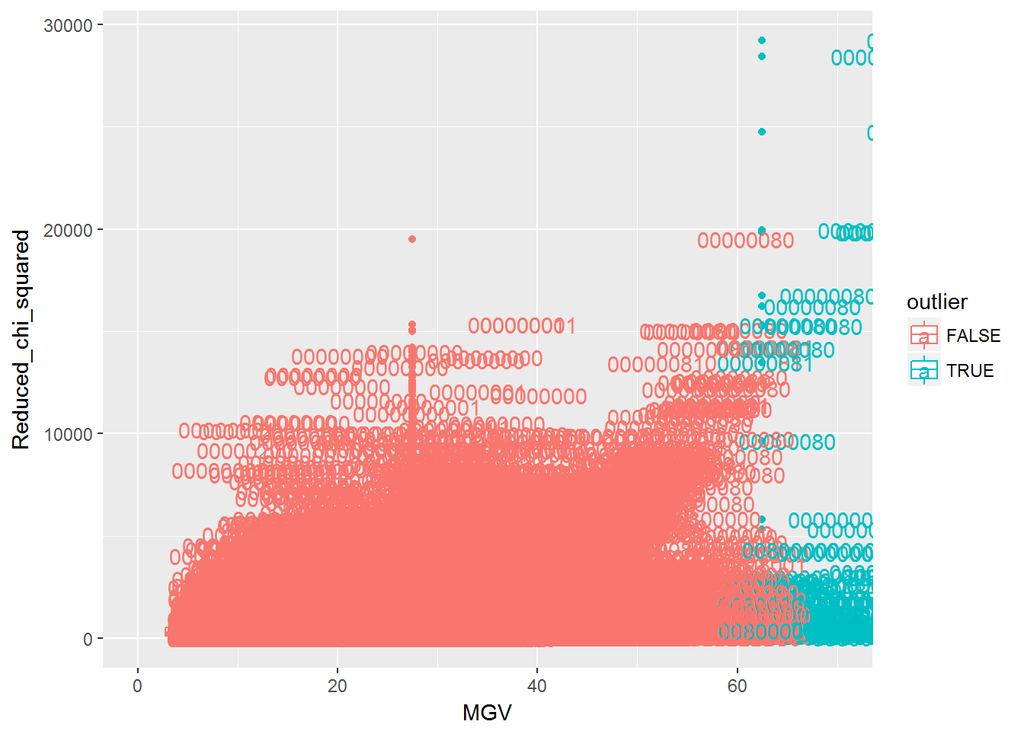

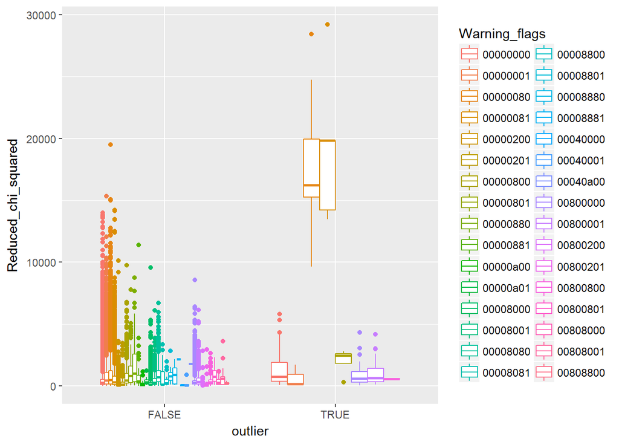

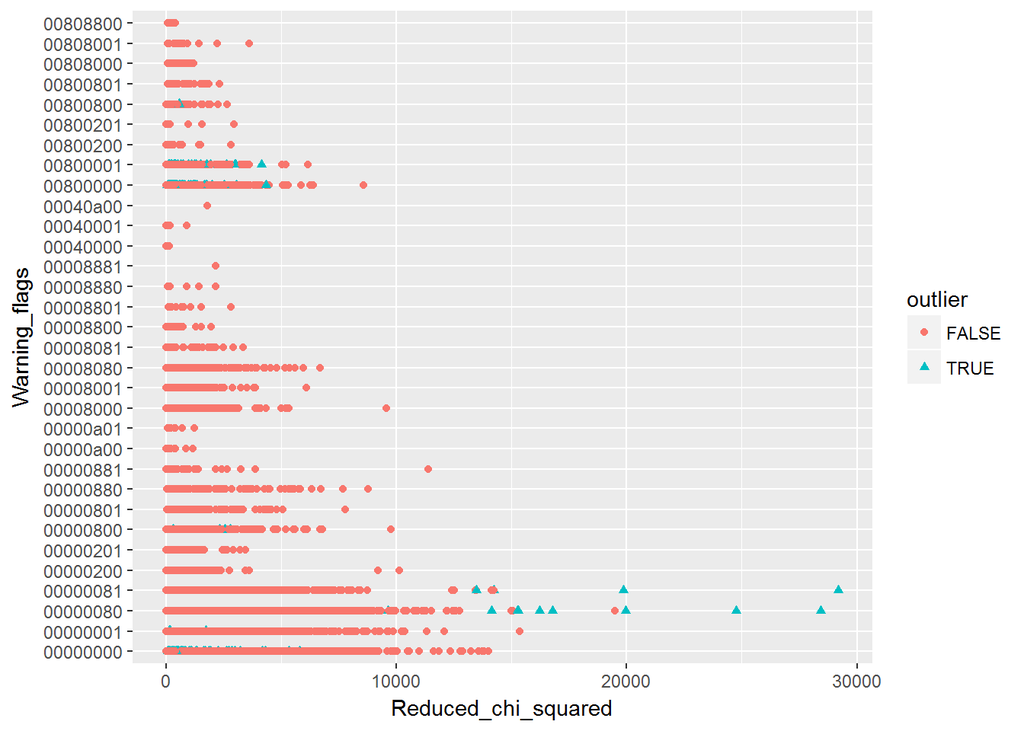

## Pour le poids sur essieu 2

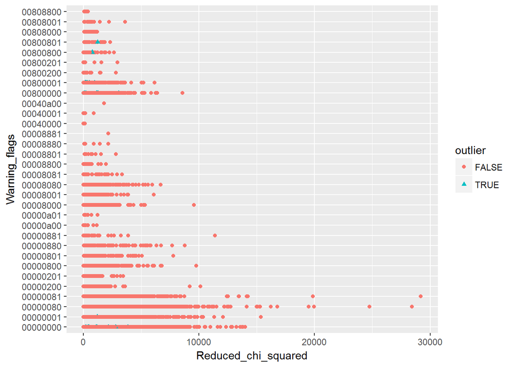

## Pour la vitesse

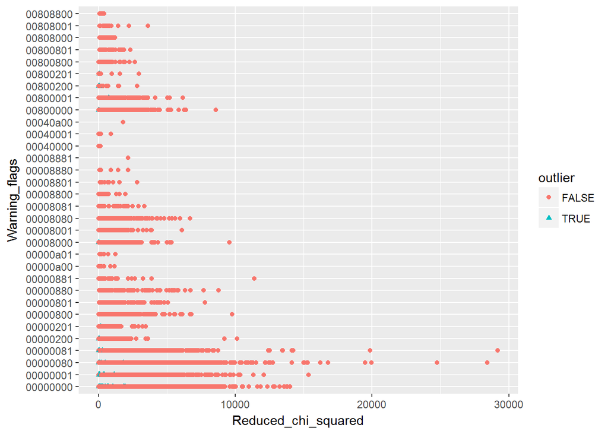